# CSC321H5 Project 3.

### Part (d) -- 2 pts

Include your training curves for the **best** models from each of Q2(a) and Q2(b). These are the models that you will use in Question 4.

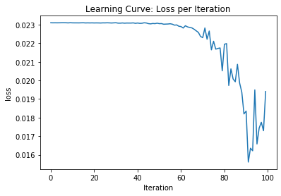

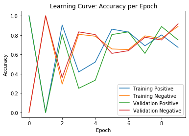

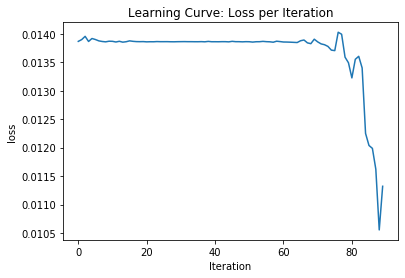

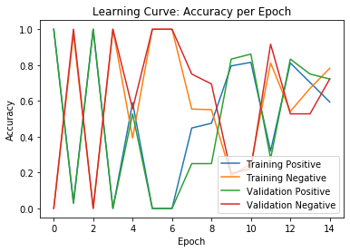

```python
# Include the training curves for the two models.
plot_learning_curve(*learning_curve_info3)
plot_learning_curve(*learning_curve_info4)
```

## Question 4.

### Part (a) -- 3 pts

Report the test accuracies of your **single best** model, separately for the two test sets. Do this by choosing the checkpoint of the model architecture that produces the best validation accuracy. That is, if your model attained the best validation accuracy in epoch 12, then the weights at epoch 12 is what you should be using to report the test accuracy.

```python
# Write your code here. Make sure to include the test accuracy in your report
test_pos_acc_m, test_neg_acc_m = get_accuracy(mod3, test_m)
test_pos_acc_w, test_neg_acc_w = get_accuracy(mod3, test_w)
print("[Test Pos Acc M %.0f%%, Test Neg Acc M %.0f%%, Test Pos Acc W %.0f%%, Test Neg Acc W %.0f%%]" % (
              test_pos_acc_m * 100, test_neg_acc_m * 100, test_pos_acc_w * 100, test_neg_acc_w * 100))
"""
Loading a checkpoint was not required for our model because it had achieved the highest validation accuracy
upon the last epoch.
"""
```

```
[Test Pos Acc M 67%, Test Neg Acc M 90%, Test Pos Acc W 67%, Test Neg Acc W 93%]
```

```
'\nLoading a checkpoint was not required for our model because it had achieved the highest validation accuracy\nupon the last epoch.\n'
```

### Part (b) -- 2 pts

Display one set of men's shoes that your model correctly classified as being from the same pair.

```
Clipping input data to the valid range for imshow with RGB data ([0..1] for floats or [0..255] for integers).
```

```
True
```

[figure not shown]

```python
same, dif = make_data(test_m)
pred = model(torch.Tensor(same[0]).unsqueeze(0).transpose(1, 3)).max(1, keepdim=True)[1]
print(bool(pred[0])) # poggers
plt.imshow(same[0])
```

### Part (c) -- 2 pts

Display one set of women's shoes that your model correctly classified as being from the same pair.

```
Clipping input data to the valid range for imshow with RGB data ([0..1] for floats or [0..255] for integers).
```

```
True
```

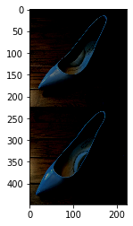

```python
same, dif = make_data(test_w)
pred = model(torch.Tensor(same[0]).unsqueeze(0).transpose(1, 3)).max(1, keepdim=True)[1]
print(bool(pred[0])) # poggers
plt.imshow(same[0])
```